# rnn

## 导入必要的库

```python
import torch
import torch.nn as nn
import torch.optim as optim
import numpy as np
import matplotlib.pyplot as plt
```

## 生成时间序列数据

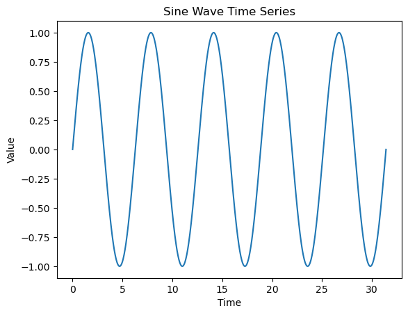

```python
# 生成正弦波数据
seq_length = 20  # 每个样本的序列长度
data_size = 1000  # 总数据量
t = np.linspace(0, 10 * np.pi, data_size)  # 时间轴
data = np.sin(t)  # 正弦波数据

# 可视化数据
plt.plot(t, data)
plt.title("Sine Wave Time Series")
plt.xlabel("Time")
plt.ylabel("Value")
plt.show()
```

## 准备训练数据

```python
# 将数据转换为PyTorch张量
data = torch.FloatTensor(data).view(-1)

# 创建输入和输出序列
def create_sequences(data, seq_length):
    xs, ys = [], []
    for i in range(len(data) - seq_length):
        x = data[i:i + seq_length]  # 输入序列
        y = data[i + seq_length]    # 输出值（下一个时间步的值）
        xs.append(x)
        ys.append(y)
    return torch.stack(xs), torch.stack(ys)

# 创建训练数据
X, y = create_sequences(data, seq_length)
```

## 定义RNN模型

```python
class SimpleRNN(nn.Module):
    def __init__(self, input_size, hidden_size, output_size):
        super(SimpleRNN, self).__init__()
        self.hidden_size = hidden_size
        self.rnn = nn.RNN(input_size, hidden_size, batch_first=True)  # RNN层
        self.fc = nn.Linear(hidden_size, output_size)  # 全连接层

    def forward(self, x):
        # 初始化隐藏状态
        h0 = torch.zeros(1, x.size(0), self.hidden_size)

        # RNN前向传播
        out, _ = self.rnn(x, h0)

        # 取最后一个时间步的输出
        out = self.fc(out[:, -1, :])
        return out

# 初始化模型
input_size = 1  # 输入特征的维度（时间序列的每个时间步是一个标量）
hidden_size = 32  # 隐藏层的神经元数量
output_size = 1  # 输出维度（预测下一个时间步的值）
model = SimpleRNN(input_size, hidden_size, output_size)
```

## 定义损失函数和优化器

```python
criterion = nn.MSELoss()  # 均方误差损失
optimizer = optim.Adam(model.parameters(), lr=0.01)  # Adam优化器
```

## 训练模型

```python
num_epochs = 100
batch_size = 32

# 创建数据加载器
dataset = torch.utils.data.TensorDataset(X, y)
dataloader = torch.utils.data.DataLoader(dataset, batch_size=batch_size, shuffle=True)

# 训练循环
for epoch in range(num_epochs):
    for batch_X, batch_y in dataloader:
        # 前向传播
        outputs = model(batch_X.unsqueeze(-1))  # 增加一个维度以匹配RNN输入格式
        loss = criterion(outputs, batch_y)

        # 反向传播和优化
        optimizer.zero_grad()
        loss.backward()
        optimizer.step()

    if (epoch + 1) % 10 == 0:
        print(f'Epoch [{epoch+1}/{num_epochs}], Loss: {loss.item():.4f}')
```

```
Epoch [10/100], Loss: 0.5080
Epoch [20/100], Loss: 0.6321
Epoch [30/100], Loss: 0.6016
Epoch [40/100], Loss: 0.5977
Epoch [50/100], Loss: 0.5153
Epoch [60/100], Loss: 0.5138
Epoch [70/100], Loss: 0.4686
Epoch [80/100], Loss: 0.3842
Epoch [90/100], Loss: 0.4577
Epoch [100/100], Loss: 0.4649
```

## 使用模型进行预测

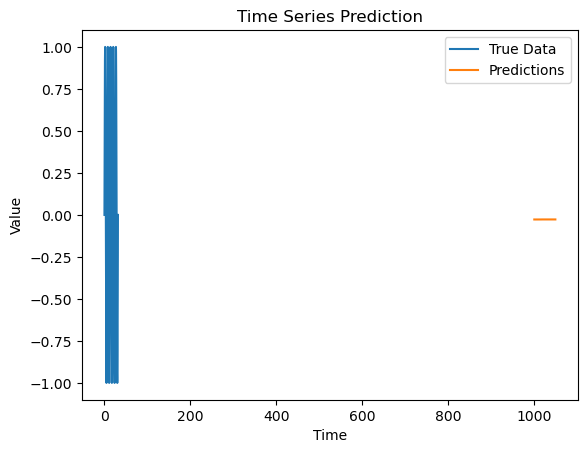

```python
# 将模型设置为评估模式
model.eval()

# 使用最后一段序列作为输入
test_input = X[-1].unsqueeze(0).unsqueeze(-1)  # 形状: (1, seq_length, 1)

# 预测未来值
future_steps = 50
predictions = []
with torch.no_grad():
    for _ in range(future_steps):
        pred = model(test_input)  # 输出形状: (1, 1)
        pred = pred.unsqueeze(-1)  # 增加特征维度，形状: (1, 1, 1)
        predictions.append(pred.item())

        # 更新输入序列
        test_input = torch.cat((test_input[:, 1:, :], pred), dim=1)  # 拼接，形状: (1, seq_length, 1)

# 可视化预测结果
plt.plot(t, data, label="True Data")
plt.plot(np.arange(len(data), len(data) + future_steps), predictions, label="Predictions")
plt.title("Time Series Prediction")
plt.xlabel("Time")
plt.ylabel("Value")
plt.legend()
plt.show()
```

# lstm

## 导入必要的库

```python
import torch
import torch.nn as nn
import numpy as np
import matplotlib.pyplot as plt
```

torch：PyTorch 核心库。

torch.nn：包含神经网络模块。

numpy：用于数据处理。

matplotlib.pyplot：用于可视化结果。

## 准备数据

```python
# 生成示例数据
def generate_time_series(num_steps):
    time = np.arange(0, num_steps)
    data = np.sin(0.1 * time) + np.random.normal(0, 0.1, size=num_steps)
    return data

# 生成数据
num_steps = 1000
data = generate_time_series(num_steps)
```

generate_time_series：生成一个正弦波加噪声的时间序列。

data：生成的时间序列数据

## 数据预处理

```python
def create_dataset(data, window_size):
    X, y = [], []
    for i in range(len(data) - window_size):
        X.append(data[i:i+window_size])
        y.append(data[i+window_size])
    return np.array(X), np.array(y)

# 设置滑动窗口大小
window_size = 20
X, y = create_dataset(data, window_size)

# 转换为 PyTorch 张量
X = torch.tensor(X, dtype=torch.float32).unsqueeze(-1)  # 形状: (样本数, 时间步长, 特征数)
y = torch.tensor(y, dtype=torch.float32)
```

将时间序列数据转换为适合 LSTM 输入的格式（滑动窗口）：

create_dataset：将时间序列数据转换为输入（X）和目标（y）对。

window_size：滑动窗口的大小，表示用过去多少个时间步来预测下一个时间步。

torch.tensor：将数据转换为 PyTorch 张量。

unsqueeze(-1)：将 X 的形状从 (样本数, 时间步长) 调整为 (样本数, 时间步长, 特征数)，以符合 LSTM 的输入要求。

## 定义 LSTM 模型

```python
class LSTMModel(nn.Module):
    def __init__(self, input_size, hidden_size, output_size):
        super(LSTMModel, self).__init__()
        self.lstm = nn.LSTM(input_size, hidden_size, batch_first=True)
        self.fc = nn.Linear(hidden_size, output_size)

    def forward(self, x):
        # LSTM 输出: (batch_size, seq_len, hidden_size)
        out, _ = self.lstm(x)
        # 只取最后一个时间步的输出
        out = self.fc(out[:, -1, :])
        return out

# 定义模型参数
input_size = 1  # 输入特征数
hidden_size = 50  # LSTM 隐藏层大小
output_size = 1  # 输出特征数

# 初始化模型
model = LSTMModel(input_size, hidden_size, output_size)
```

nn.LSTM：LSTM 层。

input_size：输入特征数。

hidden_size：隐藏层大小。

batch_first=True：输入数据的形状为 (batch_size, seq_len, input_size)。

nn.Linear：全连接层，用于将 LSTM 的输出映射到目标值。

forward：定义前向传播逻辑。

out[:, -1, :]：取 LSTM 输出的最后一个时间步的结果。

## 定义损失函数和优化器

```python
# 定义损失函数和优化器
criterion = nn.MSELoss()  # 均方误差损失
optimizer = torch.optim.Adam(model.parameters(), lr=0.01)  # Adam 优化器
```

nn.MSELoss：均方误差损失函数。

torch.optim.Adam：Adam 优化器。

## 训练模型

```python
# 训练模型
num_epochs = 20
batch_size = 32

for epoch in range(num_epochs):
    model.train()
    for i in range(0, len(X), batch_size):
        # 获取小批量数据
        X_batch = X[i:i+batch_size]
        y_batch = y[i:i+batch_size]

        # 前向传播
        outputs = model(X_batch)
        loss = criterion(outputs, y_batch)

        # 反向传播和优化
        optimizer.zero_grad()
        loss.backward()
        optimizer.step()

    print(f'Epoch [{epoch+1}/{num_epochs}], Loss: {loss.item():.4f}')
```

```
Epoch [1/20], Loss: 0.0924
Epoch [2/20], Loss: 0.0918
Epoch [3/20], Loss: 0.1278
Epoch [4/20], Loss: 0.0960
Epoch [5/20], Loss: 0.1527
Epoch [6/20], Loss: 0.1401
Epoch [7/20], Loss: 0.1376
Epoch [8/20], Loss: 0.1365
Epoch [9/20], Loss: 0.1350
Epoch [10/20], Loss: 0.1359
Epoch [11/20], Loss: 0.1343
Epoch [12/20], Loss: 0.1354
Epoch [13/20], Loss: 0.1333
Epoch [14/20], Loss: 0.1355
Epoch [15/20], Loss: 0.1259
Epoch [16/20], Loss: 0.1459
Epoch [17/20], Loss: 0.1105
Epoch [18/20], Loss: 0.1437
Epoch [19/20], Loss: 0.1054
Epoch [20/20], Loss: 0.1174
```

num_epochs：训练轮数。

batch_size：每次训练使用的小批量数据大小。

model.train()：将模型设置为训练模式。

optimizer.zero_grad()：清空梯度。

loss.backward()：反向传播计算梯度。

optimizer.step()：更新模型参数。

## 预测和可视化

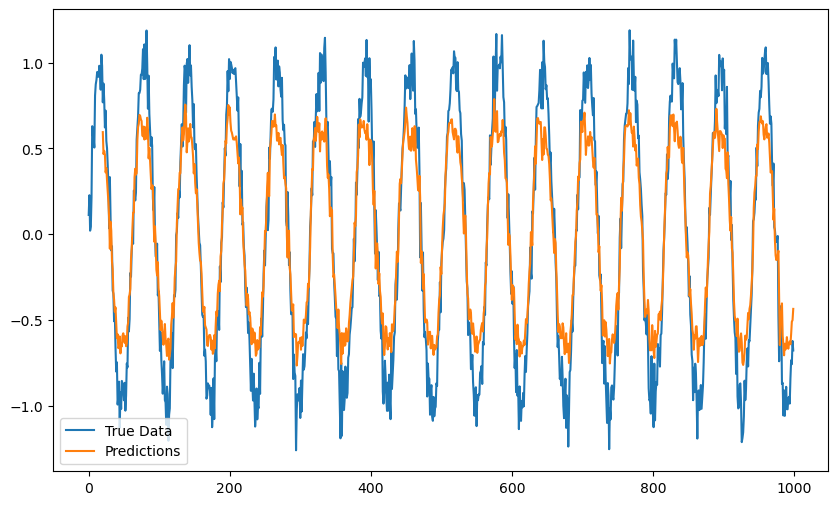

```python
# 预测
model.eval()  # 将模型设置为评估模式
with torch.no_grad():
    predictions = model(X).squeeze().numpy()

# 可视化结果
plt.figure(figsize=(10, 6))
plt.plot(data, label='True Data')
plt.plot(np.arange(window_size, len(data)), predictions, label='Predictions')
plt.legend()
plt.show()
```

model.eval()：将模型设置为评估模式。

torch.no_grad()：禁用梯度计算，节省内存。

predictions：模型预测结果。

plt.plot：绘制真实数据和预测结果的对比图。

## 完整代码

```
Epoch [1/20], Loss: 0.0619
Epoch [2/20], Loss: 0.0641
Epoch [3/20], Loss: 0.0450
Epoch [4/20], Loss: 0.1830
Epoch [5/20], Loss: 0.1075
Epoch [6/20], Loss: 0.1347
Epoch [7/20], Loss: 0.1143
Epoch [8/20], Loss: 0.1247
Epoch [9/20], Loss: 0.1190
Epoch [10/20], Loss: 0.1220
Epoch [11/20], Loss: 0.1207
Epoch [12/20], Loss: 0.1215
Epoch [13/20], Loss: 0.1214
Epoch [14/20], Loss: 0.1214
Epoch [15/20], Loss: 0.1216
Epoch [16/20], Loss: 0.1213
Epoch [17/20], Loss: 0.1212
Epoch [18/20], Loss: 0.1203
Epoch [19/20], Loss: 0.1183
Epoch [20/20], Loss: 0.1036
```

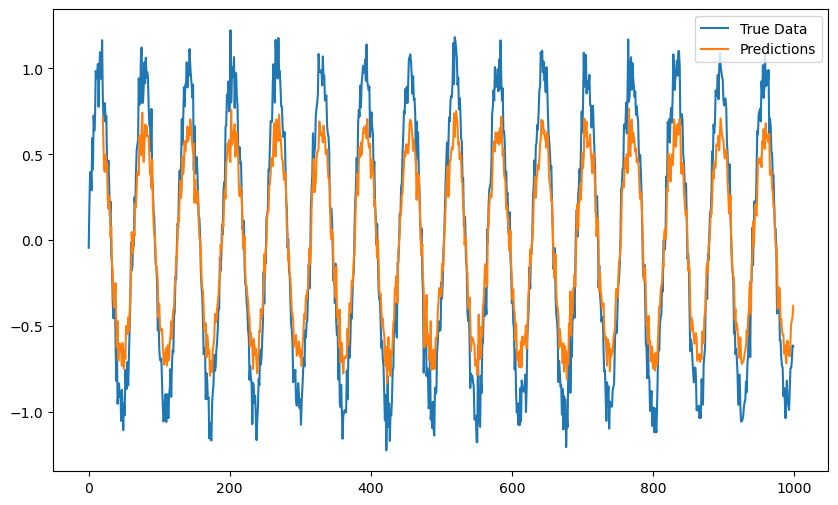

```python
import torch
import torch.nn as nn
import numpy as np
import matplotlib.pyplot as plt

# 生成示例数据
def generate_time_series(num_steps):
    time = np.arange(0, num_steps)
    data = np.sin(0.1 * time) + np.random.normal(0, 0.1, size=num_steps)
    return data

# 创建数据集
def create_dataset(data, window_size):
    X, y = [], []
    for i in range(len(data) - window_size):
        X.append(data[i:i+window_size])
        y.append(data[i+window_size])
    return np.array(X), np.array(y)

# 生成数据
num_steps = 1000
data = generate_time_series(num_steps)

# 设置滑动窗口大小
window_size = 20
X, y = create_dataset(data, window_size)

# 转换为 PyTorch 张量
X = torch.tensor(X, dtype=torch.float32).unsqueeze(-1)
y = torch.tensor(y, dtype=torch.float32)

# 定义 LSTM 模型
class LSTMModel(nn.Module):
    def __init__(self, input_size, hidden_size, output_size):
        super(LSTMModel, self).__init__()
        self.lstm = nn.LSTM(input_size, hidden_size, batch_first=True)
        self.fc = nn.Linear(hidden_size, output_size)

    def forward(self, x):
        out, _ = self.lstm(x)
        out = self.fc(out[:, -1, :])
        return out

# 定义模型参数
input_size = 1
hidden_size = 50
output_size = 1

# 初始化模型
model = LSTMModel(input_size, hidden_size, output_size)

# 定义损失函数和优化器
criterion = nn.MSELoss()
optimizer = torch.optim.Adam(model.parameters(), lr=0.01)

# 训练模型
num_epochs = 20
batch_size = 32

for epoch in range(num_epochs):
    model.train()
    for i in range(0, len(X), batch_size):
        X_batch = X[i:i+batch_size]
        y_batch = y[i:i+batch_size]
        outputs = model(X_batch)
        loss = criterion(outputs, y_batch)
        optimizer.zero_grad()
        loss.backward()
        optimizer.step()
    print(f'Epoch [{epoch+1}/{num_epochs}], Loss: {loss.item():.4f}')

# 预测
model.eval()
with torch.no_grad():
    predictions = model(X).squeeze().numpy()

# 可视化结果
plt.figure(figsize=(10, 6))
plt.plot(data, label='True Data')
plt.plot(np.arange(window_size, len(data)), predictions, label='Predictions')
plt.legend()
plt.show()
```